# A3: SPL Library Checkouts

#### 17/05/2023

## Introduction

With the advancement of technology and changes in societal trends, the ways and mediums through which people engage in reading have been constantly evolving. It seems that an increasing number of individuals are transitioning from reading physical books to consuming electronic books or other forms of digital text. This report utilizes The Seattle Public Library’s dataset, which includes items checked out at least 10 times a month from 2017 to 2022, to analyze the changing trends in reading formats or mediums over time.

## Summary Information

Based on the data, we can conclude that digital reading is taking the place of physical reading. The number of checkouts of physical items at Seattle Public Library shows a decreasing trend in general, although it rebounded in 2021. **2017** has the maximum physical checkouts amount **2763572** while **2020** has the minimum amount **544671**. The number of checkouts for digital items is showing an increasing trend over time, with the maximum checkouts amount **1962294** in **2022** .

Within the physical category, **BOOK** were the most frequently borrowed items, while in the digital category, **EBOOK** were the most popular. This suggests that despite the availability of various media formats or information carriers, people’s preference for reading remains centered around books, regardless of whether they are in physical or electronic form.

By analyzing the changes in the checkout numbers of the book “So You Want to Talk About Race” across different material types over time, we can infer that the specific book’s material type changes align with the overall trend: a gradual shift from physical to digital reading. Furthermore, the checkout amount of the book in 2020 is **13525**, which is much bigger than that for the past few years. Considering its subject matter on African American nonfiction and sociology, the significant surge in checkout number for the book in 2020 may be attributed to the prevailing Black Lives Matter social movement during that period.

## The Dataset

- Who collected/published the data?

The Seattle Public Library provides the data and the Dataset owner is David Christensen.

- What are the parameters of the data (dates, number of checkouts, kinds of books, etc.)?

UsageClass, CheckoutType, MaterialType, CheckoutYear, CheckoutMounth, Checkouts, Title, ISBN, Creator, Subjects, Publisher, PublicationYear.

- How was the data collected or generated?

This data was collected by recording the number of checkouts of physical and electronic items in the Seattle Public Library each month.

- Why was the data collected?

By collecting monthly checkouts data for physical and electronic items, Seattle Public Library can know how people check out and return books to better manage their collections. In addition, by analyzing these circulation data, it is possible to understand changes in borrowing and reading preferences and social trends, so that the collection or equipment amounts can be changed and decisions can be made more effectively for the library’s planning and development.

- What, if any, ethical questions do you need to consider when working with this data?

I think this dataset does not raise any significant ethical concerns since it primarily focuses on general reading preferences without involving any personal or sensitive information.

- What are possible limitations or problems with this data? (at least 200 words)

One limitation of this dataset is the absence of checkout data for certain years in some item categories, without providing any specific reasons. For example, the data for music in digital checkouts only spans from 2017 to 2018. Without further information, it is unclear whether this gap is due to missing data or a decline in interest in this particular format. This omission significantly impacts the analysis of reading popularity trends over time, as it fails to capture potential shifts in preferences. In addition, this dataset does not include the check out duration of items. It cannot distinguish whether people read a certain reading material intensively or extensively and cannot better analyze people’s preferences. Also, this dataset appears to be quite confusing and is not very readable. The inconsistency in the case of the title of checkouts leads to multiple rows representing the same book within a given time period, making it difficult to accurately count the check out occurrences. It would greatly improve the dataset’s usability and clarity if the titles were consistently formatted to avoid duplications and enhance readability.

## Chart 1

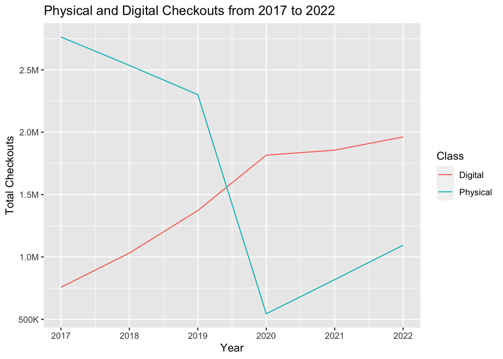

The line chart depicts the total number of physical and digital items checked out between 2017 and 2022 and how that has changed over time.

### Purpose

I would like to know the changing trends in different checkouts over time and the amount relationship between physical and digital formats.

### Insights

From the plot, we can find that the number of digital checkouts is increasing over time while the number of physical checkouts is decreasing from 2017 to 2020 and increasing from 2020 to 2022. From 2017 to around May 2019, the number of checkouts for digital items was lower than that of physical items. However, starting from May 2019, the number of digital checkouts consistently exceeded the number of physical checkouts.

## Chart 2

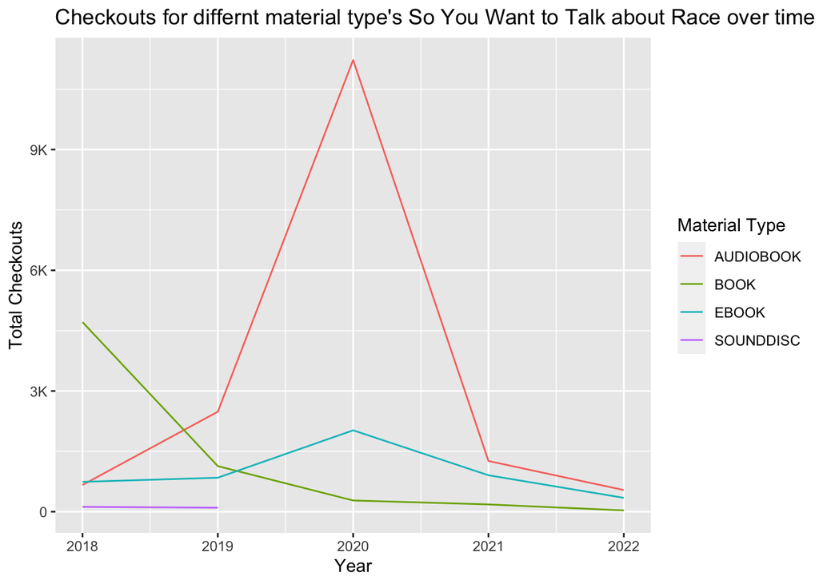

### Purpose

I would like to know if the change in the material types of a particular book checked out is the same as the general trend: digital reading is gradually replacing physical reading?

## Chart 3

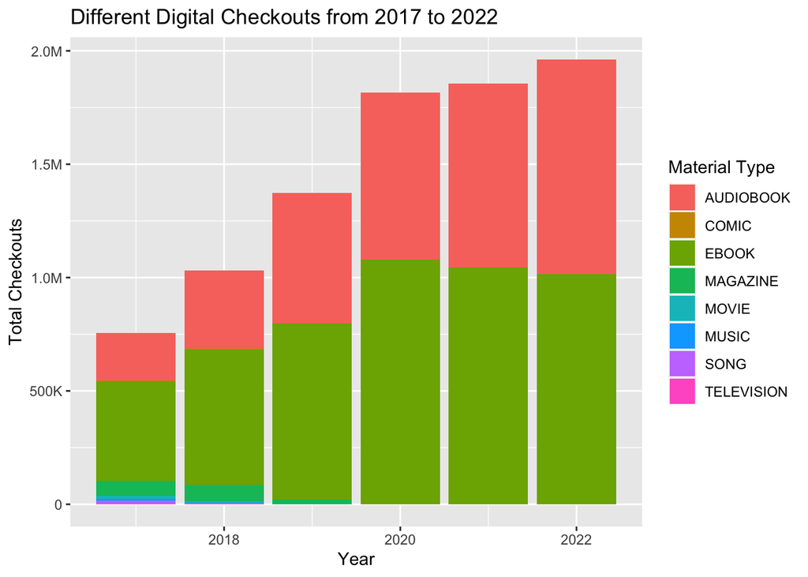

The stacked bar chart depicts the number of digital checkouts of different material types as a percentage of total digital checkouts over time and the change in the total number of digital checkouts over time.

### Purpose

I would like to know the number and percentage of different material types in the digital class and how they change over time.